# cornavirus-cases_latest

```r
library(gtools)
library(testthat)
library(ggplot2)
library(tidyverse)
library(httr)
library(DBI)
library(lubridate)
library(ggrepel)
library(RcppRoll)
```

## Goals

- To understand the data available from cornavirus.data.gov.uk - what it can and can’t tell you ()

https://theconversation.com/why-are-coronavirus-rates-rising-in-some-areas-of-england-and-not-others-147160

**Ideas to followup:**

- Faceting or grouping by indicies of multiple deprivation
- Variation of hospital statistics
- Co-variation specimen and report date
- Group LAs by newcase at end of lockdown …

## Setup project

```r
test_file("tests/test-covid_helper_functions.R")
```

```
## v |  OK F W S | Context
##
/ |   0       | covid_helper_functions
v |   2       | covid_helper_functions
##
## == Results =====================================================================================================================================
## OK:       2
## Failed:   0
## Warnings: 0
## Skipped:  0
```

```r
update_from_api = FALSE
```

## 1. Cronavirus datasets

### Latest cases CSV

```r
cases_latest <- read_csv("./Data/coronavirus-cases_latest.csv")
sample_n_from_df(cases_latest, 10)
```

```
## # A tibble: 10 x 7
##    `Area name` `Area code` `Area type` `Specimen date` `Daily lab-conf~
##    <chr>       <chr>       <chr>       <date>                     <dbl>
##  1 Newham      E09000025   utla        2020-04-15                    18
##  2 Winchester  E07000094   ltla        2020-09-14                     1
##  3 Bradford    E08000032   ltla        2020-09-16                   121
##  4 Redbridge   E09000026   utla        2020-05-24                     0
##  5 Darlington  E06000005   ltla        2020-07-19                     1
##  6 Kensington~ E09000020   ltla        2020-08-22                     2
##  7 Sheffield   E08000019   ltla        2020-05-30                    17
##  8 London      E12000007   region      2020-04-29                   431
##  9 Waltham Fo~ E09000031   utla        2020-03-26                    34
## 10 Worcester   E07000237   ltla        2020-03-18                     0
## # ... with 2 more variables: `Cumulative lab-confirmed cases` <dbl>,
## #   `Cumulative lab-confirmed cases rate` <dbl>
```

```r
cases_latest %>%
  select(`Area type`) %>%
  distinct()
```

```
## # A tibble: 4 x 1
##   `Area type`
##   <chr>
## 1 ltla
## 2 nation
## 3 region
## 4 utla
```

### Restrictions data

Restrictions data (07/10/2020) - https://visual.parliament.uk/research/visualisations/coronavirus-restrictions-map/

```r
restrictions <- read_csv("./Data/commonslibrary-coronavirus-restrictions-data.csv")
restrictions_local <- restrictions %>%
  filter(l_restrictions == "Local") %>%
  select(-l_url_local, -l_url_national, -l_restrictions) %>%
  select(-starts_with("l_national")) %>%
  rename(l_ltla = l_Category)

str_sub(colnames(restrictions_local), 1, 2) <- ""

restrictions_tidy <- restrictions_local %>%
  pivot_longer(cols = local_ruleofsix:local_openinghours, names_to = "restriction_type", values_to = "in_force")

restrictions_tidy
```

```
## # A tibble: 536 x 4
##    ltla                  Country restriction_type       in_force
##    <chr>                 <chr>   <chr>                     <dbl>
##  1 Birmingham            E       local_ruleofsix               0
##  2 Birmingham            E       local_householdmixing         1
##  3 Birmingham            E       local_raves                   0
##  4 Birmingham            E       local_stayinglocal            0
##  5 Birmingham            E       local_stayinghome             0
##  6 Birmingham            E       local_notstayingaway          0
##  7 Birmingham            E       local_businessclosures        0
##  8 Birmingham            E       local_openinghours            0
##  9 Blackburn with Darwen E       local_ruleofsix               0
## 10 Blackburn with Darwen E       local_householdmixing         1
## # ... with 526 more rows
```

Based on the prominent narrative that a fragmented patchwork of local measures is in place course the UK, I was expecting to observe an accompanying degree of variability in the data. However, the frequency counts for each of the local measures indicate otherwise.

```r
restrictions_tidy %>%
  group_by(restriction_type) %>%
  summarise(n = n())
```

```
## # A tibble: 8 x 2
##   restriction_type           n
##   <chr>                  <int>
## 1 local_businessclosures    67
## 2 local_householdmixing     67
## 3 local_notstayingaway      67
## 4 local_openinghours        67
## 5 local_raves               67
## 6 local_ruleofsix           67
## 7 local_stayinghome         67
## 8 local_stayinglocal        67
```

So, I took a quick look at how many distinct combinations of local measures were present in the data.

```r
restrictions_local %>%
  select(starts_with("local_")) %>%
  distinct()
```

```
## # A tibble: 3 x 8
##   local_ruleofsix local_household~ local_raves local_stayinglo~ local_stayingho~
##             <dbl>            <dbl>       <dbl>            <dbl>            <dbl>
## 1               0                1           0                0                0
## 2               0                1           0                0                0
## 3               0                1           0                1                0
## # ... with 3 more variables: local_notstayingaway <dbl>,
## #   local_businessclosures <dbl>, local_openinghours <dbl>
```

Three groups of local measures can be identified from the data:

1 - local_householdmixing only 2 - local_householdmixing and local_businessclosures 3 - local_householdmixing and local_stayinglocal

The frequency counts for each of these three groups are show below.

```r
restriction_local <- restrictions_local %>%
  unite(rest_group, starts_with(("local_"))) %>%
  group_by(rest_group) %>%
  mutate(rest_group_id = group_indices()) %>%
  ungroup()
restriction_local %>%
  group_by(rest_group_id) %>%
  summarise(n = n())
```

```
## # A tibble: 3 x 2
##   rest_group_id     n
##           <int> <int>
## 1             1    50
## 2             2     1
## 3             3    16
```

**Interim conclusion:** At the level of granularity presented in this data there is little variability in the local measures in place

```r
la_lookup <- read_csv("./Data/Lower_Tier_Local_Authority_to_Upper_Tier_Local_Authority__December_2019__Lookup_in_England_and_Wales.csv")
restriction_local %>%
  left_join(la_lookup, by = c("ltla" = "LTLA19NM"))
```

```
## # A tibble: 67 x 8
##    ltla     Country rest_group  rest_group_id   FID LTLA19CD UTLA19CD UTLA19NM
##    <chr>    <chr>   <chr>               <int> <dbl> <chr>    <chr>    <chr>
##  1 Birming~ E       0_1_0_0_0_~             1    81 E080000~ E080000~ Birmingham
##  2 Blackbu~ E       0_1_0_0_0_~             1     8 E060000~ E060000~ Blackburn~
##  3 Blackpo~ E       0_1_0_0_0_~             1     9 E060000~ E060000~ Blackpool
##  4 Bolton   E       0_1_0_0_0_~             1    57 E080000~ E080000~ Bolton
##  5 Bradford E       0_1_0_0_0_~             1    88 E080000~ E080000~ Bradford
##  6 Burnley  E       0_1_0_0_0_~             1   267 E070001~ E100000~ Lancashire
##  7 Bury     E       0_1_0_0_0_~             1    58 E080000~ E080000~ Bury
##  8 Calderd~ E       0_1_0_0_0_~             1    89 E080000~ E080000~ Calderdale
##  9 Chorley  E       0_1_0_0_0_~             1   268 E070001~ E100000~ Lancashire
## 10 County ~ E       0_1_0_0_0_~             1    45 E060000~ E060000~ County Du~
## # ... with 57 more rows
```

### Latest cases API

National only data

- `hospitalCases`

```r
# Create filters:
query_filters <- c(
    "areaType=ltla"
)

# Create the structure as a list or a list of lists:
query_structure <- list(
    # areaType  = "areaType",
    areaName = "areaName",
    areaCode = "areaCode",
    date = "date",
    newCasesByPublishDate = "newCasesByPublishDate",
    cumCasesByPublishDate = "cumCasesByPublishDate",
    cumCasesBySpecimenDateRate = "cumCasesBySpecimenDateRate",
    newCasesBySpecimenDate = "newCasesBySpecimenDate",
    cumCasesBySpecimenDate = "cumCasesBySpecimenDate",
    maleCases = "maleCases",
    femaleCases = "femaleCases",
    #newPillarOneTestsByPublishDate = "newPillarOneTestsByPublishDate",
    # cumPillarOneTestsByPublishDate = "cumPillarOneTestsByPublishDate",
    # newPillarTwoTestsByPublishDate = "newPillarTwoTestsByPublishDate",
    # cumPillarTwoTestsByPublishDate = "cumPillarTwoTestsByPublishDate",
    # newPillarThreeTestsByPublishDate = "newPillarThreeTestsByPublishDate",
    # cumPillarThreeTestsByPublishDate = "cumPillarThreeTestsByPublishDate",
    # newPillarFourTestsByPublishDate = "newPillarFourTestsByPublishDate",
    # cumPillarFourTestsByPublishDate = "cumPillarFourTestsByPublishDate",
    newAdmissions = "newAdmissions",
    cumAdmissions = "cumAdmissions",
    cumAdmissionsByAge = "cumAdmissionsByAge",
    # cumTestsByPublishDate = "cumTestsByPublishDate",
    # newTestsByPublishDate = "newTestsByPublishDate",
    covidOccupiedMVBeds = "covidOccupiedMVBeds",
    hospitalCases = "hospitalCases",
    # plannedCapacityByPublishDate = "plannedCapacityByPublishDate",
    newDeaths28DaysByPublishDate = "newDeaths28DaysByPublishDate",
    cumDeaths28DaysByPublishDate = "cumDeaths28DaysByPublishDate",
    cumDeaths28DaysByPublishDateRate = "cumDeaths28DaysByPublishDateRate",
    newDeaths28DaysByDeathDate = "newDeaths28DaysByDeathDate",
    cumDeaths28DaysByDeathDate = "cumDeaths28DaysByDeathDate",
    cumDeaths28DaysByDeathDateRate = "cumDeaths28DaysByDeathDateRate"
)

if (update_from_api){

  result <- get_paginated_data(query_filters, query_structure)
  result <- as_tibble(result)

  cases_latest_db <- dbConnect(RSQLite::SQLite(), "cases_latest_db.sqlite")
  dbWriteTable(cases_latest_db, "cases", result, overwrite = TRUE)

  dbDisconnect(cases_latest_db)
}
```

```r
cases_latest_db <- dbConnect(RSQLite::SQLite(), "cases_latest_db.sqlite")


cases <- as_tibble(dbGetQuery(cases_latest_db, "SELECT * FROM cases"))
dbDisconnect(cases_latest_db)

cases <- cases %>%
  mutate(date = as_date(date))

cases %>%
  sample_n(10)
```

```
## # A tibble: 10 x 21
##    areaName areaCode date       newCasesByPubli~ cumCasesByPubli~
##    <chr>    <chr>    <date>                <int>            <int>
##  1 Chiltern E070000~ 2020-06-29                0               NA
##  2 Bolton   E080000~ 2020-02-05                0               NA
##  3 North K~ E070001~ 2020-08-01                0               NA
##  4 Brentwo~ E070000~ 2020-10-01                7               NA
##  5 Blaenau~ W060000~ 2020-02-06                0               NA
##  6 Reading  E060000~ 2020-03-05                0               NA
##  7 Aberdee~ S120000~ 2020-07-01                0               NA
##  8 Renfrew~ S120000~ 2020-02-03                0               NA
##  9 Eden     E070000~ 2020-06-08                0               NA
## 10 North E~ E060000~ 2020-05-01                0               NA
## # ... with 16 more variables: cumCasesBySpecimenDateRate <dbl>,
## #   newCasesBySpecimenDate <int>, cumCasesBySpecimenDate <int>,
## #   maleCases <int>, femaleCases <int>, newAdmissions <int>,
## #   cumAdmissions <int>, cumAdmissionsByAge <int>, covidOccupiedMVBeds <int>,
## #   hospitalCases <int>, newDeaths28DaysByPublishDate <int>,
## #   cumDeaths28DaysByPublishDate <int>, cumDeaths28DaysByPublishDateRate <dbl>,
## #   newDeaths28DaysByDeathDate <int>, cumDeaths28DaysByDeathDate <int>,
## #   cumDeaths28DaysByDeathDateRate <dbl>
```

Drop columns where all values are NA

```r
cases <- cases %>%
  select_if(~sum(!is.na(.)) > 0)
cases
```

```
## # A tibble: 107,240 x 13
##    areaName areaCode date       newCasesByPubli~ cumCasesByPubli~
##    <chr>    <chr>    <date>                <int>            <int>
##  1 Aberdee~ S120000~ 2020-10-08               31             1525
##  2 Aberdee~ S120000~ 2020-10-07               24             1494
##  3 Aberdee~ S120000~ 2020-10-06                7             1470
##  4 Aberdee~ S120000~ 2020-10-05               15             1463
##  5 Aberdee~ S120000~ 2020-10-04               19             1448
##  6 Aberdee~ S120000~ 2020-10-03               11             1429
##  7 Aberdee~ S120000~ 2020-10-02               17             1418
##  8 Aberdee~ S120000~ 2020-10-01               16             1401
##  9 Aberdee~ S120000~ 2020-09-30               32             1385
## 10 Aberdee~ S120000~ 2020-09-29               34             1353
## # ... with 107,230 more rows, and 8 more variables:
## #   cumCasesBySpecimenDateRate <dbl>, newCasesBySpecimenDate <int>,
## #   cumCasesBySpecimenDate <int>, newDeaths28DaysByPublishDate <int>,
## #   cumDeaths28DaysByPublishDate <int>, cumDeaths28DaysByPublishDateRate <dbl>,
## #   cumDeaths28DaysByDeathDate <int>, cumDeaths28DaysByDeathDateRate <dbl>
```

Calculate moving averages

```r
cases <- cases %>%
  mutate(mm_newCasesBySpecimenDate = roll_mean(newCasesBySpecimenDate, n = 7, align="center", fill = 0))

cases
```

```
## # A tibble: 107,240 x 14
##    areaName areaCode date       newCasesByPubli~ cumCasesByPubli~
##    <chr>    <chr>    <date>                <int>            <int>
##  1 Aberdee~ S120000~ 2020-10-08               31             1525
##  2 Aberdee~ S120000~ 2020-10-07               24             1494
##  3 Aberdee~ S120000~ 2020-10-06                7             1470
##  4 Aberdee~ S120000~ 2020-10-05               15             1463
##  5 Aberdee~ S120000~ 2020-10-04               19             1448
##  6 Aberdee~ S120000~ 2020-10-03               11             1429
##  7 Aberdee~ S120000~ 2020-10-02               17             1418
##  8 Aberdee~ S120000~ 2020-10-01               16             1401
##  9 Aberdee~ S120000~ 2020-09-30               32             1385
## 10 Aberdee~ S120000~ 2020-09-29               34             1353
## # ... with 107,230 more rows, and 9 more variables:
## #   cumCasesBySpecimenDateRate <dbl>, newCasesBySpecimenDate <int>,
## #   cumCasesBySpecimenDate <int>, newDeaths28DaysByPublishDate <int>,
## #   cumDeaths28DaysByPublishDate <int>, cumDeaths28DaysByPublishDateRate <dbl>,
## #   cumDeaths28DaysByDeathDate <int>, cumDeaths28DaysByDeathDateRate <dbl>,
## #   mm_newCasesBySpecimenDate <dbl>
```

### Population data

https://www.ons.gov.uk/peoplepopulationandcommunity/populationandmigration/populationestimates/datasets/populationestimatesforukenglandandwalesscotlandandnorthernireland

```r
pop_df <-read_csv("./Data/ons_mid_2019_population_estimates.csv")
pop_df <- pop_df %>%
  rename(all_ages = `All ages`)
pop_df
```

```
## # A tibble: 426 x 95
##    Code  Name  Geography1 all_ages    `0`    `1`    `2`    `3`    `4`    `5`
##    <chr> <chr> <chr>         <dbl>  <dbl>  <dbl>  <dbl>  <dbl>  <dbl>  <dbl>
##  1 K020~ UNIT~ Country    66796807 722881 752554 777309 802334 802185 809152
##  2 K030~ GREA~ Country    64903140 700160 729146 753103 777260 777225 784154
##  3 K040~ ENGL~ Country    59439840 649388 676412 698837 720721 719821 726317
##  4 E920~ ENGL~ Country    56286961 618858 644056 665596 686135 684992 691122
##  5 E120~ NORT~ Region      2669941  26621  27612  28621  29575  29315  30224
##  6 E060~ Coun~ Unitary A~   530094   4890   5085   5292   5483   5597   5826
##  7 E060~ Darl~ Unitary A~   106803   1100   1152   1112   1218   1208   1257
##  8 E060~ Hart~ Unitary A~    93663   1006   1009   1031   1125   1058   1126
##  9 E060~ Midd~ Unitary A~   140980   1802   1944   1979   1886   1972   1957
## 10 E060~ Nort~ Unitary A~   322434   2665   2952   2996   3146   3006   3129
## # ... with 416 more rows, and 85 more variables: `6` <dbl>, `7` <dbl>,
## #   `8` <dbl>, `9` <dbl>, `10` <dbl>, `11` <dbl>, `12` <dbl>, `13` <dbl>,
## #   `14` <dbl>, `15` <dbl>, `16` <dbl>, `17` <dbl>, `18` <dbl>, `19` <dbl>,
## #   `20` <dbl>, `21` <dbl>, `22` <dbl>, `23` <dbl>, `24` <dbl>, `25` <dbl>,
## #   `26` <dbl>, `27` <dbl>, `28` <dbl>, `29` <dbl>, `30` <dbl>, `31` <dbl>,
## #   `32` <dbl>, `33` <dbl>, `34` <dbl>, `35` <dbl>, `36` <dbl>, `37` <dbl>,
## #   `38` <dbl>, `39` <dbl>, `40` <dbl>, `41` <dbl>, `42` <dbl>, `43` <dbl>,
## #   `44` <dbl>, `45` <dbl>, `46` <dbl>, `47` <dbl>, `48` <dbl>, `49` <dbl>,
## #   `50` <dbl>, `51` <dbl>, `52` <dbl>, `53` <dbl>, `54` <dbl>, `55` <dbl>,
## #   `56` <dbl>, `57` <dbl>, `58` <dbl>, `59` <dbl>, `60` <dbl>, `61` <dbl>,
## #   `62` <dbl>, `63` <dbl>, `64` <dbl>, `65` <dbl>, `66` <dbl>, `67` <dbl>,
## #   `68` <dbl>, `69` <dbl>, `70` <dbl>, `71` <dbl>, `72` <dbl>, `73` <dbl>,
## #   `74` <dbl>, `75` <dbl>, `76` <dbl>, `77` <dbl>, `78` <dbl>, `79` <dbl>,
## #   `80` <dbl>, `81` <dbl>, `82` <dbl>, `83` <dbl>, `84` <dbl>, `85` <dbl>,
## #   `86` <dbl>, `87` <dbl>, `88` <dbl>, `89` <dbl>, `90+` <dbl>
```

## Exploratory data analysis

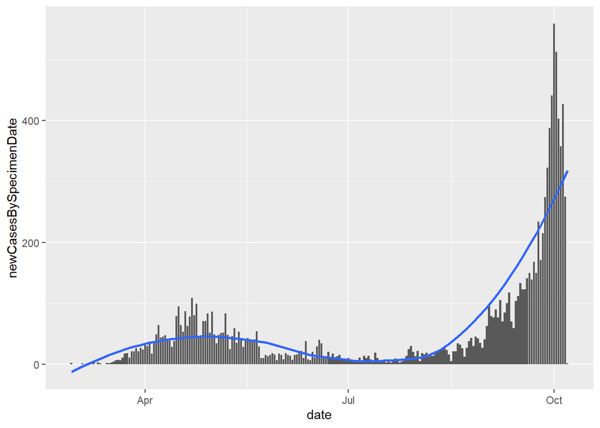

```r
cases %>%
  filter(areaName == "Leeds") %>%

  ggplot(aes(x = date, y = newCasesBySpecimenDate)) +

  geom_col() +
  geom_smooth(se = FALSE)
```

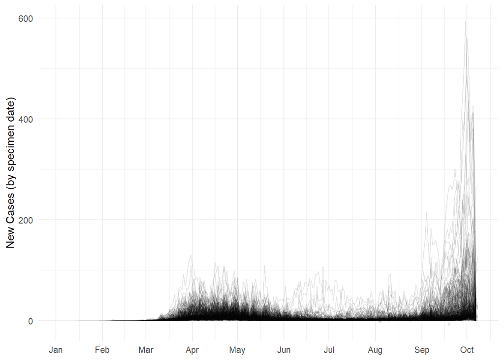

```r
p <- ggplot(data = cases,
            mapping = aes(x = date,
                          y = newCasesBySpecimenDate,
                          group = areaName)
            )

p + geom_line(alpha = 0.1) +

  scale_x_date(date_breaks = "1 month",
               date_labels = "%b") +

  labs(x = NULL,
       y = "New Cases (by specimen date)"
       ) +

  theme_minimal()
```

Use newcases moving mean (1 week)

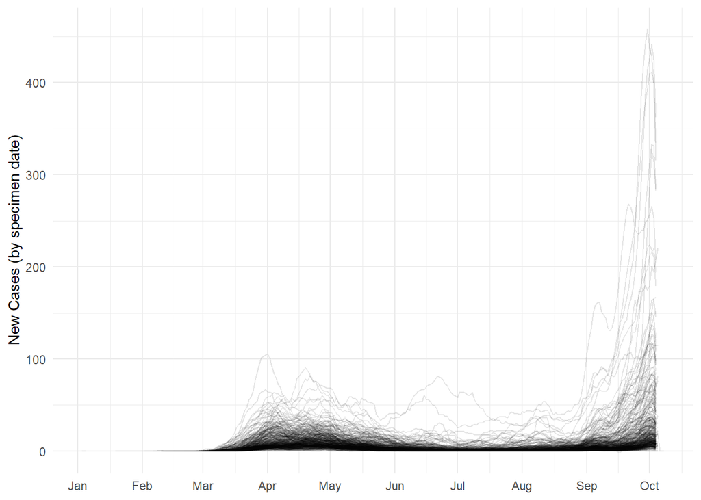

```r
p <- ggplot(data = cases,
            mapping = aes(x = date,
                          y = mm_newCasesBySpecimenDate,
                          group = areaName)
            )

p + geom_line(alpha = 0.1) +

  scale_x_date(date_breaks = "1 month",
               date_labels = "%b") +

  labs(x = NULL,
       y = "New Cases (by specimen date)"
       ) +

  theme_minimal()
```

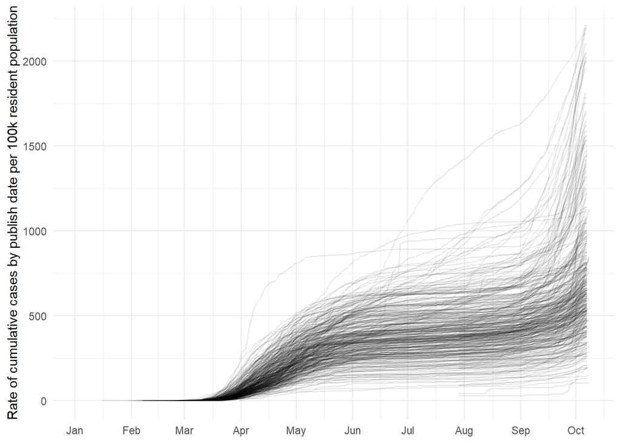

```r
p <- ggplot(data = cases,
            mapping = aes(x = date,
                          y = cumCasesBySpecimenDateRate,
                          group = areaName)
            )

p + geom_line(alpha = 0.1) +

  scale_x_date(date_breaks = "1 month",
               date_labels = "%b") +

  labs(x = NULL,
       y = "Rate of cumulative cases by publish date per 100k resident population"
       ) +

  theme_minimal()
```

To look at new cases per 100,000 population, make use of ONS population date

```r
pop_df_minimal <- pop_df %>%
  select(Code, all_ages)

pop_df_minimal
```

```
## # A tibble: 426 x 2
##    Code      all_ages
##    <chr>        <dbl>
##  1 K02000001 66796807
##  2 K03000001 64903140
##  3 K04000001 59439840
##  4 E92000001 56286961
##  5 E12000001  2669941
##  6 E06000047   530094
##  7 E06000005   106803
##  8 E06000001    93663
##  9 E06000002   140980
## 10 E06000057   322434
## # ... with 416 more rows
```

Noticed negative newCase numbers, resulting in negative rates

```r
cases_pop <- cases %>%
  left_join(pop_df_minimal, by = c("areaCode" = "Code")) %>%
  mutate(newCasesBySpecimenDateRate = (newCasesBySpecimenDate / all_ages) * 1e05)

sample_n_from_df(cases_pop, 10)
```

```
## # A tibble: 10 x 16
##    areaName areaCode date       newCasesByPubli~ cumCasesByPubli~
##    <chr>    <chr>    <date>                <int>            <int>
##  1 Wyre Fo~ E070002~ 2020-04-13                0               NA
##  2 Lincoln  E070001~ 2020-08-13                0               NA
##  3 Bassetl~ E070001~ 2020-01-11                0               NA
##  4 Tower H~ E090000~ 2020-04-25                4               NA
##  5 Charnwo~ E070001~ 2020-07-11               10               NA
##  6 Knowsley E080000~ 2020-09-19               31               NA
##  7 South A~ S120000~ 2020-02-10                0               NA
##  8 Ashford  E070001~ 2020-09-13                1               NA
##  9 Forest ~ E070000~ 2020-10-08               10              255
## 10 Arun     E070002~ 2020-09-13                2               NA
## # ... with 11 more variables: cumCasesBySpecimenDateRate <dbl>,
## #   newCasesBySpecimenDate <int>, cumCasesBySpecimenDate <int>,
## #   newDeaths28DaysByPublishDate <int>, cumDeaths28DaysByPublishDate <int>,
## #   cumDeaths28DaysByPublishDateRate <dbl>, cumDeaths28DaysByDeathDate <int>,
## #   cumDeaths28DaysByDeathDateRate <dbl>, mm_newCasesBySpecimenDate <dbl>,
## #   all_ages <dbl>, newCasesBySpecimenDateRate <dbl>
```

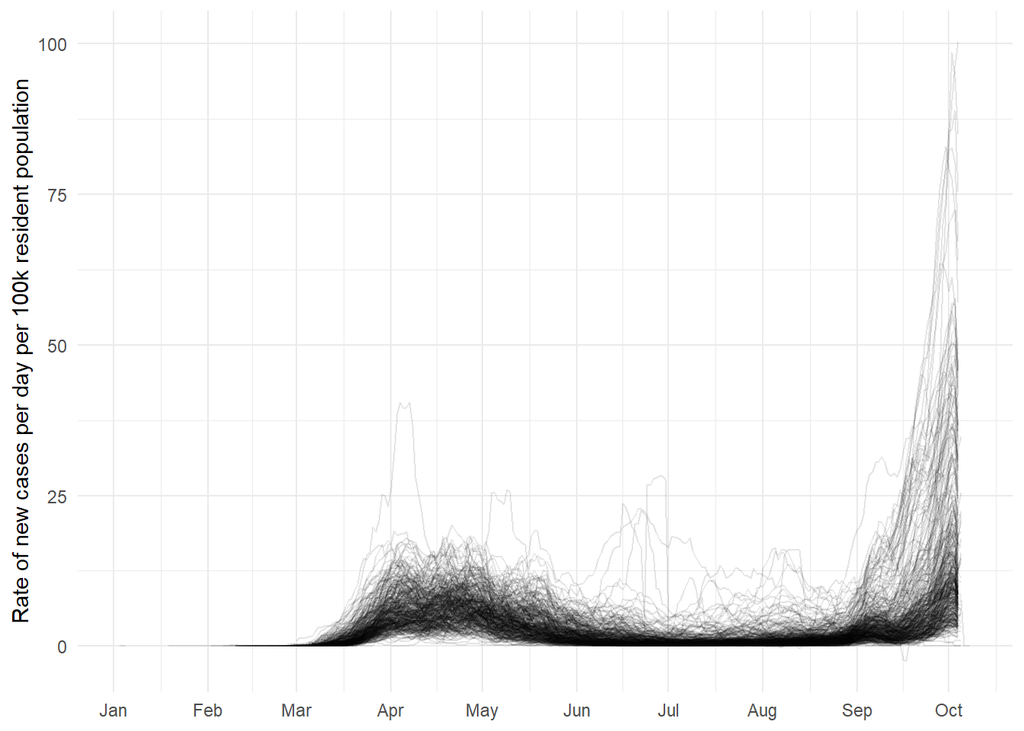

```r
p <- ggplot(data = cases_pop,
            mapping = aes(x = date,
                          #y = newCasesBySpecimenDateRate,
                          y = roll_mean(newCasesBySpecimenDateRate, n =7, align = "center", fill = 0),
                          group = areaName)
            )

p + geom_line(alpha = 0.1) +

  scale_x_date(date_breaks = "1 month",
               date_labels = "%b") +

  labs(x = NULL,
       y = "Rate of new cases per day per 100k resident population"
       ) +

  theme_minimal()
```

Look at a two window centred on 1st July - around the minimum

```r
july_first_case_summary <- cases_pop %>%
  filter(date >= "2020-06-24") %>%
  filter(date <= "2020-07-08") %>%
  group_by(areaName) %>%
  summarise(mean_new_case_rate_jul1 = mean(newCasesBySpecimenDateRate))
```

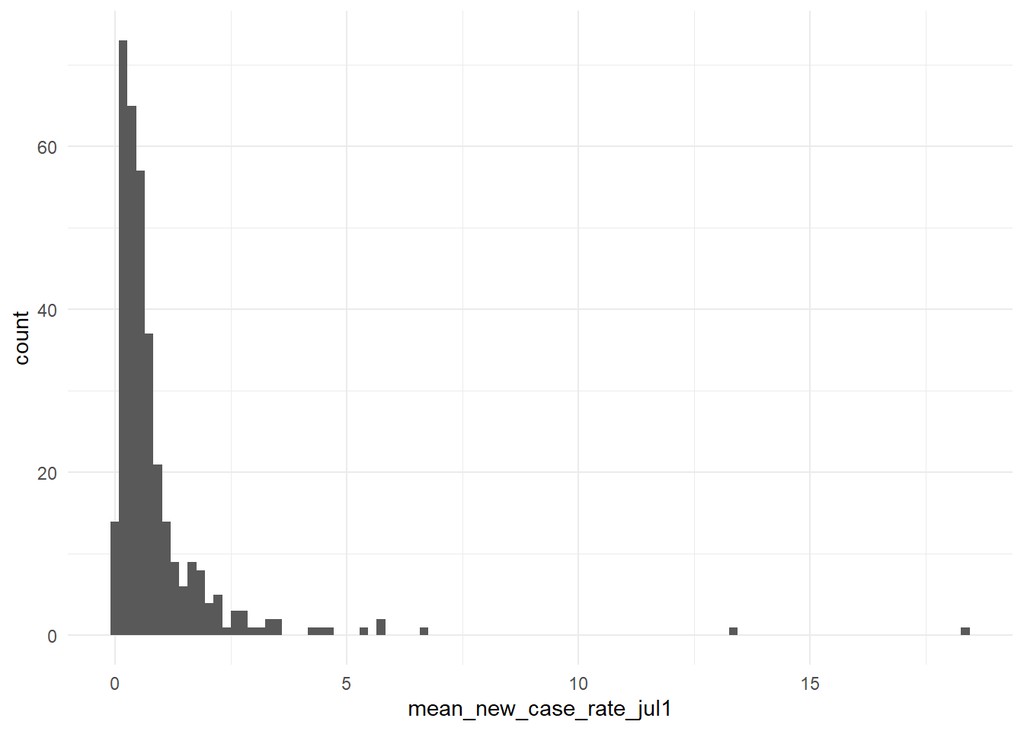

```r
  #mutate(quantile = quantcut(mean_new_case_rate, na.rm = TRUE)) %>%

july_first_case_summary %>%
  ggplot(mapping = aes(x = mean_new_case_rate_jul1)) +

  geom_histogram(bins = 100) +

  theme_minimal()
```

```r
summary(july_first_case_summary)
```

```
##    areaName         mean_new_case_rate_jul1
##  Length:383         Min.   : 0.0000
##  Class :character   1st Qu.: 0.2692
##  Mode  :character   Median : 0.5244
##                     Mean   : 0.8963
##                     3rd Qu.: 0.9410
##                     Max.   :18.3500
##                     NA's   :39
```

```r
july_first_case_summary <- july_first_case_summary %>%
  mutate(quantile_new_case_rate_jul1 = quantcut(mean_new_case_rate_jul1, na.rm = TRUE))

cases_pop <- cases_pop %>%
  left_join(july_first_case_summary)
```

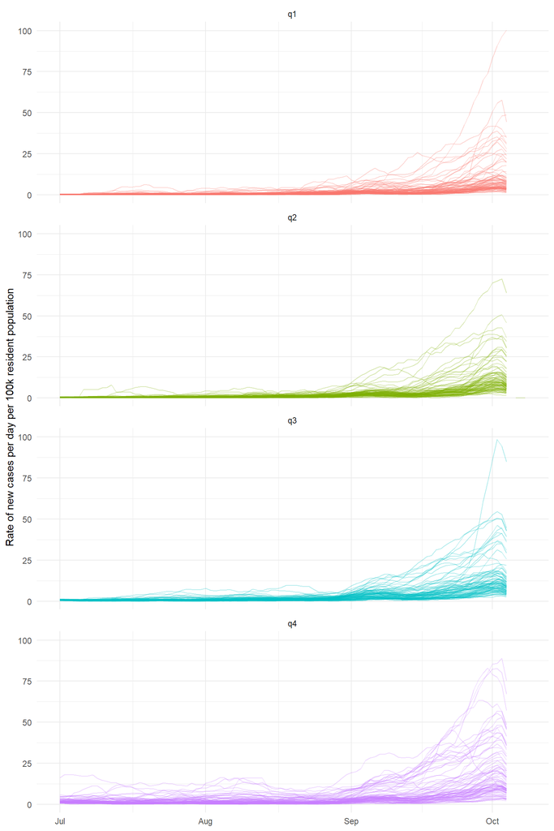

```r
facet_labs <- c(`[0,0.269]` = "q1", `(0.269,0.524]` = "q2", `(0.524,0.941]` = "q3", `(0.941,18.3]` = "q4")

p <- ggplot(data = subset(cases_pop, !is.na(quantile_new_case_rate_jul1)),
            mapping = aes(x = date,
                          #y = newCasesBySpecimenDateRate,
                          y = roll_mean(newCasesBySpecimenDateRate, n =7, align = "center", fill = 0),
                          group = areaName,
                          colour = quantile_new_case_rate_jul1
                          )
            )

p + geom_line(alpha = 0.3) +

  facet_wrap(~quantile_new_case_rate_jul1, ncol = 1,
             labeller=labeller(quantile_new_case_rate_jul1 = facet_labs)) +

  scale_x_date(date_breaks = "1 month",
               date_labels = "%b",
               limits =  c(as_date("2020-07-01"), NA)
               ) +

  labs(x = NULL,
       y = "Rate of new cases per day per 100k resident population"
       ) +

  theme_minimal() +
  theme(legend.position = "none")
```

### September

Let’s take a look at the variability in case numbers across local authorities across September.

Labeled with grey text - local authorities without restrictions, and amongst the 50 local authorities with the highest rates. Labeled with light blue text - the one local authority subject to business closures.

```r
sept_cases <- cases_pop %>%
  filter(date >= as_date("2020-09-01")) %>%
  filter(date < as_date("2020-10-01")) %>%

  # remove Scotland data from case data, as restriction data for Scotland is not available
  filter(!str_detect(areaCode, "^S")) %>%

  left_join(restriction_local, by = c("areaName" = "ltla")) %>%

  group_by(areaName) %>%
  summarise(sept_new_cases_by_specimen_date = sum(newCasesBySpecimenDate),
            mean_case_rate = mean(newCasesBySpecimenDateRate),
            restrictions = median(rest_group_id, na.rm = TRUE)
            ) %>%
  mutate(mean_case_rate_rank = min_rank(desc(mean_case_rate)))
```

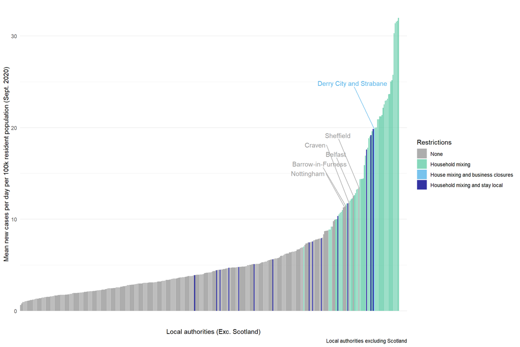

```r
sept_cases$restrictions[is.na(sept_cases$restrictions)] <- 0
sept_cases$restrictions <- as_factor(sept_cases$restrictions)

ggplot(data = sept_cases, mapping = aes(x = reorder(areaName, mean_case_rate),
                                        y = mean_case_rate)
       ) +

  geom_col(aes(fill = restrictions), alpha = 0.8) +
  geom_text_repel(data = subset(sept_cases, restrictions == 2),
                  mapping = aes(label = areaName),
                  nudge_x = -20,
                  nudge_y = 5,
                  colour = "#56B4E9"
                  ) +

    geom_text_repel(data = subset(sept_cases,
                                  restrictions == 0 & mean_case_rate_rank <= 50
                                  ),
                  mapping = aes(label = areaName),
                  nudge_x = -25,
                  nudge_y = 5,
                  colour = "grey60"
                  ) +

  scale_x_discrete(labels = NULL) +
  scale_fill_manual(values=c("grey60", "aquamarine3", "#56B4E9", "blue4"),
                    labels = c("None", "Household mixing", "House mixing and business closures", "Household mixing and stay local" )
                    ) +

  labs(x = "Local authorities (Exc. Scotland)",
       y = "Mean new cases per day per 100k resident population (Sept. 2020)",
       fill = "Restrictions",
       caption = "Local authorities excluding Scotland") +

  theme_minimal() +
  theme(panel.grid.major.x = element_blank())
```

```r
# ggplot(data = sept_cases, mapping = aes(x = newCasesBySpecimenDate), group = areaName) +
#   geom_histogram(binwidth = 1) +
#
#   scale_x_continuous(limits = c(0,100)) +
#
#   theme_minimal()
```

## Covariation

```r
head(cases)
```

```
## # A tibble: 6 x 14
##   areaName areaCode date       newCasesByPubli~ cumCasesByPubli~
##   <chr>    <chr>    <date>                <int>            <int>
## 1 Aberdee~ S120000~ 2020-10-08               31             1525
## 2 Aberdee~ S120000~ 2020-10-07               24             1494
## 3 Aberdee~ S120000~ 2020-10-06                7             1470
## 4 Aberdee~ S120000~ 2020-10-05               15             1463
## 5 Aberdee~ S120000~ 2020-10-04               19             1448
## 6 Aberdee~ S120000~ 2020-10-03               11             1429
## # ... with 9 more variables: cumCasesBySpecimenDateRate <dbl>,
## #   newCasesBySpecimenDate <int>, cumCasesBySpecimenDate <int>,
## #   newDeaths28DaysByPublishDate <int>, cumDeaths28DaysByPublishDate <int>,
## #   cumDeaths28DaysByPublishDateRate <dbl>, cumDeaths28DaysByDeathDate <int>,
## #   cumDeaths28DaysByDeathDateRate <dbl>, mm_newCasesBySpecimenDate <dbl>
```

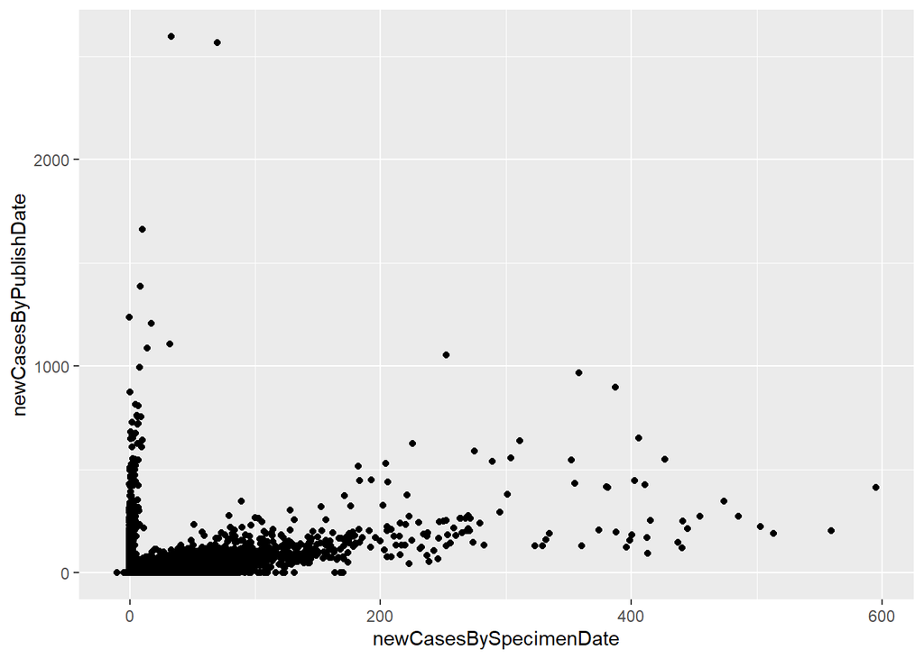

```r
p <- ggplot(data = cases, mapping = aes(x = newCasesBySpecimenDate, y = newCasesByPublishDate))

p + geom_jitter()
```

*Scatter plot cases vs deaths